# WGS Analysis of OAC organoids and matched tissues

2025-05-13

The aim of this script is to summarise the WGS data of our OAC organoids and matched tissues. This includes:

- Summary of all potential driver mutations and alterations, as defined using the 76 established OAC-linked driver genes (Frankell et al. 2019)
- Comparisons of linked features including TMB, ploidy, HRD index score, and mutational signatures
- Concordance analysis to establish similarities between matched organoid/tissue pairs

```r
library(readxl) # to load in excel files
library(tidyverse) # table manipulation
```

```r
library(biomaRt) # Ensembl access
library(ggplot2) # Plotting
library(ggpubr) # Additional plotting potential
library(scarHRD) # HRD index score calculation
library(vcfR) # to read VCF files
library(deconstructSigs) # Mutational signature fitting
library(BSgenome.Hsapiens.UCSC.hg19) # for determine SBS96 trinucleotide context
library(lsa) # for cosine similarity calculation
library(ComplexHeatmap) # for oncoplot
library(circlize) # for color Ramp
```

# 1 Data Preprocessing

As a preliminary step, since we will only be analysing OAC driver genes, we can load in this list

```r
gene_drivers.file <- read_excel('Results/41588_2018_331_MOESM3_ESM.xlsx',
                                sheet = 'ST9 All Drivers dnds ratios',
                                skip = 2)
gene_drivers <- gene_drivers.file$gene_name
```

We will also organise our respective metadata in order to ensure that there is only one organoid/tissue per case, and all cases are OAC cases from the OCCAMS consortium

```r
meta <- read.csv('Data/case_sex_spec_pheno_source_site_pass_seq_strat_oc748_20250513.csv', row.names = 1)

meta.wgs <- meta %>%
  dplyr::filter(strategy == 'whole-genome' &
           # grepl(pattern = 'OCCAMS', case_id) &
           specimen_phenotype == 'oac' &
           specimen_source %in% c('tissue','organoid'))

# Remove following tissues (duplicated, and sequenced in separate batch)
cases_remove.dupTissue <- c('LP6008460-DNA_H03','PD44940a','PD44783a','LP2101132-DNA_A01')

meta.wgs <- meta.wgs %>%
  dplyr::filter(!(sequence_id %in% cases_remove.dupTissue))

# Relabel the case_id for specimen OC/AH/453/L/T4 (this is staging lap for CAM453)
meta.wgs$case_id[meta.wgs$specimen_id == 'OC/AH/453/L/T4'] <- 'OCCAMS/AH/453L'

# Remove late-passage organoids ('NA' is equivalent to 1)
#   In cases with equal passage values, the first alphabetically is selected
meta.wgs_organoid <- meta.wgs %>% dplyr::filter(specimen_source == 'organoid')
meta.wgs_organoid$passage[is.na(meta.wgs_organoid$passage)] <- 1

cases_remove.lateOrganoid <- meta.wgs_organoid %>%
  group_by(case_id) %>%
  arrange(passage, .by_group = TRUE) %>%
  dplyr::slice(-1)
cases_remove.lateOrganoid <- cases_remove.lateOrganoid$sequence_id

meta.wgs <- meta.wgs %>%
  dplyr::filter(!(sequence_id %in% cases_remove.lateOrganoid))
```

## 1.1 Sort mutation data

```r
# List respective VEP files
vep.files <- list.files(path = '.', pattern = '.pass.coding.supplemented.vep$',
                        recursive = TRUE)

# Extract VEP files matched to samples included in metadata
vep.files_sequenceID <- sapply(vep.files, function(x)
  strsplit(strsplit(x,split='/')[[1]][3],split='_vs_')[[1]][1])
vep.files_include <- vep.files_sequenceID %in% meta.wgs$sequence_id

# The following are highlighted duplicates to be removed since they were aligned to normal samples from a separate batch
vep.files_include[5:6] <- FALSE # OC/AH/388
vep.files_include[39:40] <- FALSE # OC/AH/446
vep.files_include[43:44] <- FALSE # OC/AH/433
vep.files_include[65:66] <- FALSE # OC/AH/574 organoid
vep.files_include[69:70] <- FALSE # OC/AH/574 tissue

vep.files <- vep.files[vep.files_include]

# Collate all VEP files into a single data frame, additionally highlighting the gene, mutationID, and mutation type, noting that each file has either 16 or 18 columns.

vep.full <- data.frame()

for (file in vep.files) {

  if (readLines(file) %>% length > 1) { # do not read tables without any data inside

    vep.i <- read.delim(file, skip=1, header = FALSE)

    if (ncol(vep.i) == 18) {

      vep.i <- vep.i[,c(1,2,3,11,18)]
      names(vep.i) <- c('occams.ID','sequence_id','mutationID','mutationType','Extra')
      vep.i <- vep.i %>% dplyr::filter(!duplicated(mutationID))
      vep.i$Gene <- sapply(vep.i$Extra, function(x)
        strsplit(strsplit(x,split=';')[[1]][2],split='=')[[1]][2])

      vep.full <- rbind(vep.full, vep.i[,-5]) # remove column 'Extra'

    } else if (ncol(vep.i) == 16) {

      # For some reason, the newest batch has 'M' at V1 instead of the OCCAMS_ID
      if (grepl(pattern='SLX-21369',file)) vep.i$V1 = 'OCCAMS/AH/748'

      # Additionally, samples from OCCAMS/AH/574 and OCCAMS/AH/576 have mislabelled sequence IDs
      if (grepl(pattern = '2126_WTSI-OESO_224', file) | grepl(pattern = '2126_WTSI-OESO_211', file)) {
        vep.i[,2] <- sapply(vep.i[,2], function(x)
          str_replace(x, pattern = '1631', replacement = '2126'))
      }

      vep.i <- vep.i[,c(1,2,3,9,16)]
      names(vep.i) <- c('occams.ID','sequence_id','mutationID','mutationType','Extra')
      vep.i <- vep.i %>% dplyr::filter(!duplicated(mutationID))
      vep.i$Gene <- sapply(vep.i$Extra, function(x)
        strsplit(strsplit(x,split=';')[[1]][2],split='=')[[1]][2])

      vep.full <- rbind(vep.full, vep.i[,-5]) # remove column 'Extra'

    } else {

      print(paste0('Check number of columns in file: ',file))

    }

  }

}

# Subset for OAC driver genes, and extract sequence_id for OAC sample
vep.oac <- vep.full %>% dplyr::filter(Gene %in% gene_drivers)
vep.oac$sequence_id <- sapply(vep.oac$sequence_id, function(x)
  strsplit(x,split='_vs_')[[1]][1])

# Match with metadata and add specimen source information
vep.oac <- merge(x = vep.oac, y = meta.wgs[,c('sequence_id','specimen_source')])

# Fix mismatches in the OCCAMS IDs
vep.oac$occams.ID <- sapply(vep.oac$occams.ID, function(x) gsub('OC/AH/','OCCAMS/AH/',x))
vep.oac$occams.ID <- sapply(vep.oac$occams.ID, function(x) gsub('^AH/','OCCAMS/AH/',x))

# Add in CAM453L for staging lap
vep.oac$occams.ID[vep.oac$sequence_id == '1631_WTSI-OESO_095_1pre'] <- 'OCCAMS/AH/453L'
```

## 1.2 Sort copy number data

Copy number and ploidy information are gathered by loading Caveman output and then matching this with the positions of the OAC driver genes extracted from Ensembl. Note that this data was aligned to the GRCh37 (hg19) reference genome, and therefore an archive database is used.

```r
# Load positions of OAC driver genes
# mart = useMart(biomart="ENSEMBL_MART_ENSEMBL", host="feb2014.archive.ensembl.org", path="/biomart/martservice", dataset="hsapiens_gene_ensembl")
load('~/Documents/Data/mart.homosapiens.hg19.Rdata')
gene_positions <- getBM(
  attributes = c('hgnc_symbol','chromosome_name','start_position','end_position'),
  filters = c('hgnc_symbol'),
  values = list(gene_drivers),
  mart=mart
)
gene_positions <- gene_positions %>% filter(chromosome_name %in% c(1:22,'X','Y'))

# List caveman and ploidy files
files.caveman <- list.files(pattern = '.copynumber.caveman.csv', recursive = TRUE)
files.ploidy <- list.files(pattern = 'samplestatistics.csv', recursive = TRUE)

files.caveman <- files.caveman[-c(3,7,13,22,24,35,37)]
files.ploidy <- files.ploidy[-c(3,7,13,22,24,35,37)]

# Define 'by' statement for joining with caveman output
by = join_by(
  chromosome_name == Chromosome,
  start_position >= Start,
  end_position <= End
)

# Now we ascribe the CNVs
cnv.full <- data.frame()

for (i in 1:length(files.caveman)) {

  # Extract ploidy, which will be used to define alterations
  ploidy.i <- read.delim(files.ploidy[i],h=F,sep=' ')[2,2]

  # Load caveman information and merge with gene_positions
  caveman.i <- read.csv(files.caveman[i])
  caveman.i$Chromosome <- as.character(caveman.i$Chromosome)
  genes.i <- left_join(gene_positions, caveman.i, by)

  # Label CNVs based on Li, Francies et al. 2018
  genes.i$CNV <- NA
  # genes.i$CNV[genes.i$Total_CN >= 1.25*ploidy.i] <- 'Gain'
  # genes.i$CNV[genes.i$Minor_CN == 0] <- 'LOH'
  genes.i$CNV[genes.i$Total_CN >= 2*ploidy.i] <- 'Amplification'
  # genes.i$CNV[genes.i$Total_CN <= 0.75*ploidy.i] <- 'Loss'
  genes.i$CNV[genes.i$Total_CN == 0] <- 'Deletion'

  genes.i <- genes.i %>% filter(!is.na(CNV))

  if (nrow(genes.i) > 0) {

    # Extract sequencingID for matching
    genes.i$sequence_id <- strsplit(strsplit(files.caveman[i], split='/')[[1]][3],split='_vs_')[[1]][1]
    cnv.full <- rbind(cnv.full, genes.i)

  }

}

# Match with metadata to obtain case_id/specimen_source, then align with vep.oac
cnv.full <- merge(x = cnv.full, y = meta.wgs[,c('sequence_id','specimen_source','case_id')])
cnv.oac <- cnv.full [,c('case_id', 'sequence_id', 'hgnc_symbol', 'specimen_source', 'CNV')]
names(cnv.oac) <- c('occams.ID','sequence_id','Gene','specimen_source','mutationType')

# Fix CAM453 staging lap
cnv.oac$occams.ID[cnv.oac$sequence_id == '1631_WTSI-OESO_095_1pre'] <- 'OCCAMS/AH/453L'

# Finally, combine the mutation and copy number profiles
muts.oac <- rbind(vep.oac[,c('occams.ID','sequence_id','Gene','specimen_source','mutationType')], cnv.oac)

print(paste0('Proportion of driver alterations in organoids which are amplifications or deletions: ',
             100*round(mean(muts.oac$mutationType[muts.oac$specimen_source == 'organoid'] %in% c('Amplification','Deletion')),4),'%'))
```

```
## [1] "Proportion of driver alterations in organoids which are amplifications or deletions: 21.4%"
```

## 1.3 Sort Birmingham organoids

This analysis will be containing two organoids obtained from OCCAMS patients from Birmingham, and processed at the Sanger Institute as part of the Cell Model Networks project. Data for the respective organoids was obtained from Cell Model Passports.

```r
# Sample 1: WTSI-OESO_117 (HCM-SANG-0311-C15-B)
muts.oeso117 <- read.csv('Data/organoids_Birmingham/CMP_HCM-SANG-0311-C15-B_mutations.csv')
muts.oeso117$occams.ID <- 'OESO/117'
muts.oeso117$sequence_id <- 'HCM-SANG-0311-C15-B'
muts.oeso117$specimen_source <- 'organoid'
muts.oeso117 <- muts.oeso117 %>% filter(Symbol %in% gene_drivers)
names(muts.oeso117)[c(1,7)] <- c('Gene','mutationType')
muts.oeso117$mutationType[muts.oeso117$mutationType == 'undefined'] <-
  muts.oeso117$Driver.alteration[muts.oeso117$mutationType == 'undefined']
muts.oeso117 <- muts.oeso117[,names(muts.oac)]

# Sample 2: WTSI-OESO_146 (HCM-SANG-0309-C15)
muts.oeso146 <- read.csv('Data/organoids_Birmingham/CMP_HCM-SANG-0309-C15_mutations.csv')
muts.oeso146$occams.ID <- 'OESO/146'
muts.oeso146$sequence_id <- 'HCM-SANG-0309-C15'
muts.oeso146$specimen_source <- 'organoid'
muts.oeso146 <- muts.oeso146 %>% filter(Symbol %in% gene_drivers)
names(muts.oeso146)[c(1,7)] <- c('Gene','mutationType')
muts.oeso146$mutationType[muts.oeso146$mutationType == 'undefined'] <-
  muts.oeso146$Driver.alteration[muts.oeso146$mutationType == 'undefined']
muts.oeso146 <- muts.oeso146[,names(muts.oac)]

# Merge Birmingham organoids
muts.oac <- rbind(muts.oac, muts.oeso117, muts.oeso146)
```

One of the lovely challengers created by merging datasets is that mutation-type labels are marginally different! Now let’s fix those mutation labels.

```r
# Initial step: subset for relevant mutation types
muts.oac <- muts.oac %>% filter(grepl(pattern = 'missense', mutationType) |
                                  grepl(pattern = 'frameshift', mutationType) |
                                  grepl(pattern = 'stop_gained', mutationType) |
                                  grepl(pattern = 'nonsense', mutationType) |
                                  grepl(pattern = 'inframe_', mutationType) |
                                  grepl(pattern = 'NMD_transcript_variant', mutationType) |
                                  mutationType %in% c('Deletion','Amplification') # Note that Gain/Loss are currently removed here
                                )

# Highlight hierarchy of mutation types
muts.oac$mutationType[grepl(pattern = 'NMD_transcript_variant', muts.oac$mutationType)] <- 'NMD_transcript_variant'
muts.oac$mutationType[muts.oac$mutationType == 'frameshift_variant,splice_region_variant'] <- 'frameshift_variant'
muts.oac$mutationType[muts.oac$mutationType == 'missense_variant,splice_region_variant'] <- 'missense_variant'

muts.oac$mutationType[muts.oac$mutationType == 'nonsense'] <- 'stop_gained'
muts.oac$mutationType[muts.oac$mutationType == 'frameshift'] <- 'frameshift_variant'
muts.oac$mutationType[muts.oac$mutationType == 'missense'] <- 'missense_variant'
```

For the sake of posterity, let us also do some plotting to summarise the coding data we have.

```
## `summarise()` has regrouped the output.
## ℹ Summaries were computed grouped by occams.ID, specimen_source, and
##   mutationType.
## ℹ Output is grouped by occams.ID and specimen_source.
## ℹ Use `summarise(.groups = "drop_last")` to silence this message.
## ℹ Use `summarise(.by = c(occams.ID, specimen_source, mutationType))` for
##   per-operation grouping (`?dplyr::dplyr_by`) instead.
```

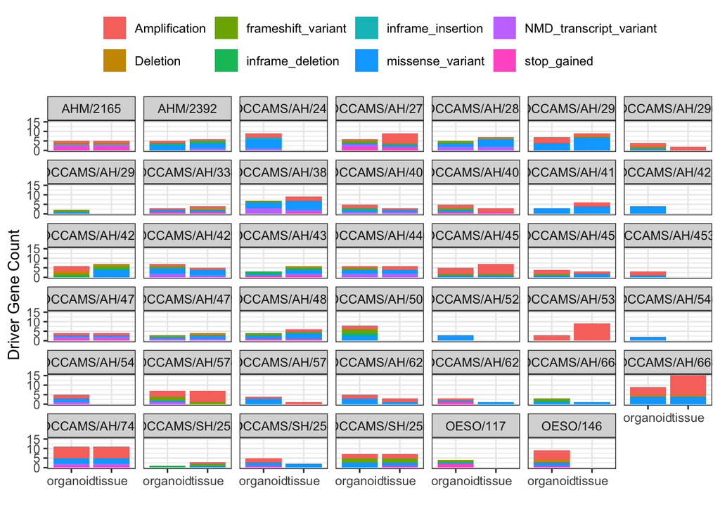

```r
muts.oac %>%
  group_by(occams.ID, specimen_source, mutationType) %>%
  summarise(count = n()) %>%
  ggplot(aes(x = specimen_source, y = count, fill = mutationType)) +
  theme_bw() + geom_bar(stat = 'identity') + facet_wrap(~occams.ID) +
  theme(legend.position = 'top', legend.title = element_blank()) +
  labs(x='', y='Driver Gene Count')
```

# 2 Prepare additional information

At this point, we can begin collating additional functional genomic information about the tissues and organoids. These can be profiled separately, and then will be combined in order to provide functional annotation for our resulting oncoplot

## 2.1 Tumour Mutation Burden

Conveniently, total SNV and indel counts are stored in .txt files as outputted from strelka processing. Therefore, all we need to do is collate these files. Fortunately, these are saved in the same order as our VEP files, and therefore can be filtered as such

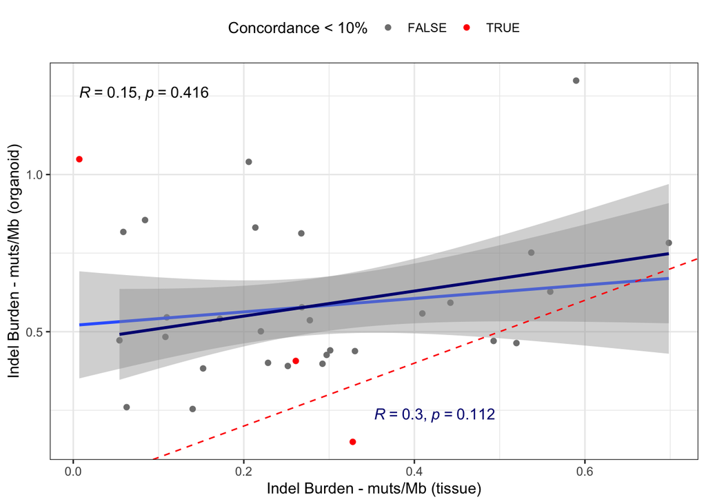

```r
# List .txt files
files.tmb <- list.files('Data/strelka', pattern = 'txt$', recursive = TRUE, full.names = TRUE)
files.tmb <- files.tmb[vep.files_include]

# For each file, extract the sequence ID from the file name, save SNV/indel type, and extract TMB
df.tmb <- data.frame()

for (file in files.tmb) {

  sequence_id <- strsplit(strsplit(file, split='/')[[1]][3], split='_vs_')[[1]][1]
  mut_type <- ifelse(grepl(pattern = 'indel', file), 'indel', 'SNV')
  tmb <- read.table(file)[1,1]

  df.tmb.i <- data.frame(sequence_id, mut_type, tmb)
  df.tmb <- rbind(df.tmb, df.tmb.i)

}

# Combine with metadata (for the sake of initial comparison)
df.tmb <- merge(x = df.tmb, y = meta.wgs[,c('sequence_id','case_id','specimen_source')])

# Plot concordance in TMB for indels and SNVs
df.tmb %>%
  dplyr::filter(mut_type == 'indel') %>%
  mutate(`Concordance < 10%` = case_id %in% c('OCCAMS/SH/253','OCCAMS/AH/576','OCCAMS/AH/283')) %>%
  # dplyr::filter(`Concordance < 10%` == FALSE) %>%
  mutate(tmb = tmb/3100) %>% # to translate to muts/Mb
  dplyr::select(-sequence_id) %>%
  pivot_wider(names_from = specimen_source, values_from = tmb) -> df.tmb_indel_compare
ggplot(df.tmb_indel_compare, aes(x = tissue, y = organoid)) + theme_bw() +
  geom_point(aes(color = `Concordance < 10%`)) +
  geom_smooth(method = 'lm') + stat_cor(p.accuracy = 0.001) +
  geom_smooth(data = df.tmb_indel_compare[df.tmb_indel_compare$`Concordance < 10%` == FALSE,], method = 'lm', color = 'navy') +
  stat_cor(data = df.tmb_indel_compare[df.tmb_indel_compare$`Concordance < 10%` == FALSE,], color = 'navy',
           label.x.npc = 'centre', label.y.npc = 'bottom', p.accuracy = 0.001) +
  labs(x = 'Indel Burden - muts/Mb (tissue)', y = 'Indel Burden - muts/Mb (organoid)') +
  theme(legend.position = 'top') +
  scale_color_manual(values = c('gray50','red')) +
  geom_abline(col = 'red', linetype = 'dashed', slope = 1, intercept = 0)
```

```r
ggsave(filename = 'Results/OrganoidsOAC_concordanceTMB_indels.pdf')
```

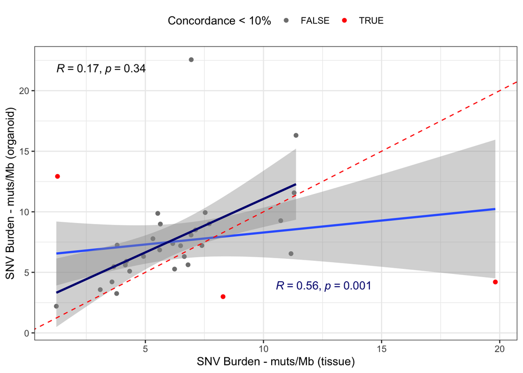

```r
df.tmb %>%
  dplyr::filter(mut_type == 'SNV') %>%
  mutate(`Concordance < 10%` = case_id %in% c('OCCAMS/SH/253','OCCAMS/AH/576','OCCAMS/AH/283')) %>%
  # dplyr::filter(`Concordance < 10%` == FALSE) %>%
  mutate(tmb = tmb/3100) %>% # to translate to muts/Mb
  dplyr::select(-sequence_id) %>%
  pivot_wider(names_from = specimen_source, values_from = tmb) -> df.tmb_snv_compare
ggplot(df.tmb_snv_compare, aes(x = tissue, y = organoid)) + theme_bw() +
  geom_point(aes(color = `Concordance < 10%`)) +
  geom_smooth(method = 'lm') + stat_cor(p.accuracy = 0.001) +
  geom_smooth(data = df.tmb_snv_compare[df.tmb_snv_compare$`Concordance < 10%` == FALSE,], method = 'lm', color = 'navy') +
  stat_cor(data = df.tmb_snv_compare[df.tmb_snv_compare$`Concordance < 10%` == FALSE,], color = 'navy',
           label.x.npc = 'centre', label.y.npc = 'bottom', p.accuracy = 0.001) +
  labs(x = 'SNV Burden - muts/Mb (tissue)', y = 'SNV Burden - muts/Mb (organoid)') +
  theme(legend.position = 'top') +
  scale_color_manual(values = c('gray50','red')) +
  geom_abline(col = 'red', linetype = 'dashed', slope = 1, intercept = 0)
```

```r
ggsave(filename = 'Results/OrganoidsOAC_concordanceTMB_SNV.pdf')
# Finally, save total TMB values
df.tmb <- df.tmb %>%
  group_by(sequence_id, case_id, specimen_source) %>%
  summarise(TMB = sum(tmb)) %>%
  mutate(TMB = TMB/3100)
```

```
## `summarise()` has regrouped the output.
## ℹ Summaries were computed grouped by sequence_id, case_id, and specimen_source.
## ℹ Output is grouped by sequence_id and case_id.
## ℹ Use `summarise(.groups = "drop_last")` to silence this message.
## ℹ Use `summarise(.by = c(sequence_id, case_id, specimen_source))` for
##   per-operation grouping (`?dplyr::dplyr_by`) instead.
```

```r
# Add the Birmingham organoids
df.tmb_birmingham <- data.frame(
  sequence_id = c('HCM-SANG-0311-C15-B','HCM-SANG-0309-C15'),
  case_id = c('OESO/117','OESO/146'),
  specimen_source = rep('organoid',2),
  TMB = c(5.07, 7.23)
)

df.tmb <- rbind(df.tmb, df.tmb_birmingham)

print(paste0('Median TMB in organoids = ',round(median(df.tmb$TMB[df.tmb$specimen_source == 'organoid']),2),'muts/Mb'))
```

```
## [1] "Median TMB in organoids = 7.43muts/Mb"
```

```r
print(paste0('Median TMB in tissues = ',round(median(df.tmb$TMB[df.tmb$specimen_source == 'tissue']),2),'muts/Mb'))
```

```
## [1] "Median TMB in tissues = 6.54muts/Mb"
```

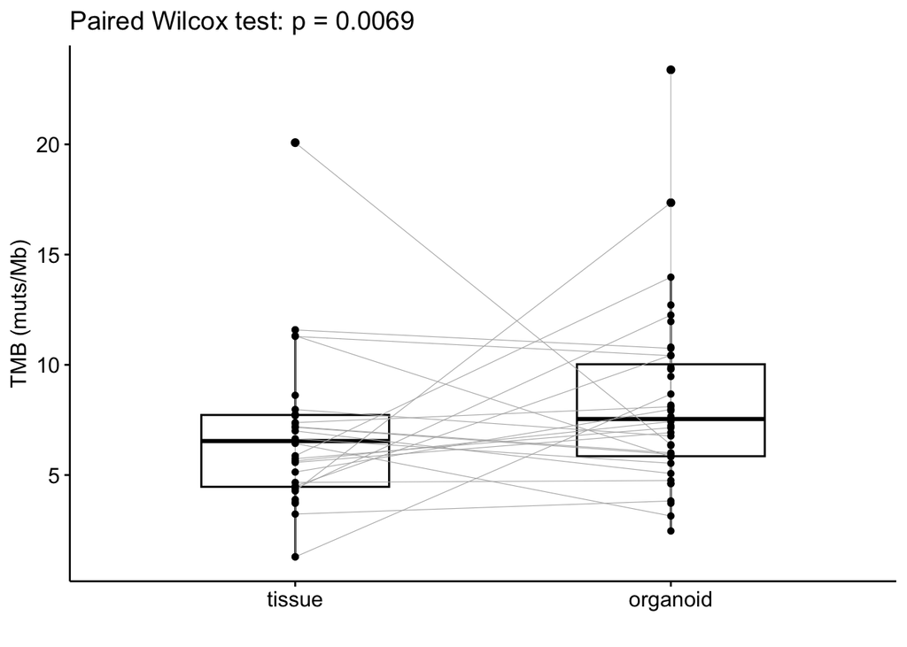

```r
# Compare all TMBs
df.tmb[,-1] %>%
  pivot_wider(names_from = specimen_source, values_from = TMB) %>%
  dplyr::filter(!is.na(tissue) & !is.na(organoid)) -> df.tmb_paired
wilcox.test(x = df.tmb_paired$tissue, y = df.tmb_paired$organoid, paired = TRUE) -> wilcox.test_pairedTMB

ggpaired(df.tmb[df.tmb$case_id != 'OCCAMS/AH/453L', ], x = 'specimen_source', y = 'TMB', line.color = 'gray70', line.size = .2) +
  labs(x = '', y = 'TMB (muts/Mb)') +
  ggtitle(paste0('Paired Wilcox test: p = ',round(wilcox.test_pairedTMB$p.value,4)))
```

```r
ggsave(filename = 'Results/OrganoidsOAC_TMB_PDOvsTissue.pdf')
```

## 2.2 Purity/ploidy

These values are calculated using ASCAT output, and are saved in the ploidy files generated earlier. We can save this in the data frame ‘df.ascatAnno’.

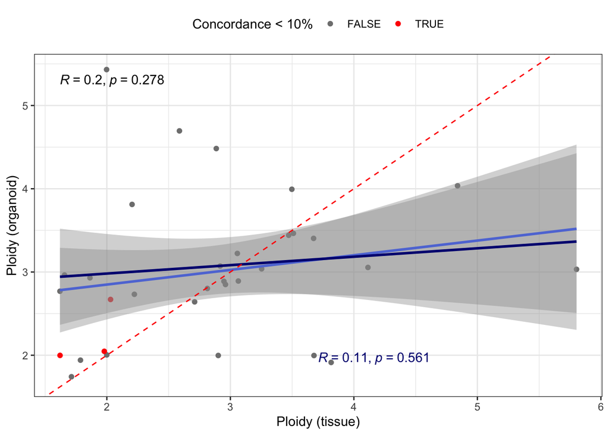

```r
df.ascatAnno <- data.frame()

for (file in files.ploidy) {

  sequence_id <- strsplit(strsplit(file, split='/')[[1]][3], split='_vs_')[[1]][1]

  file.ploidy.i <- read.delim(file, header = FALSE, sep = ' ')
  ploidy.i <- file.ploidy.i$V2[file.ploidy.i$V1 == 'Ploidy']
  purity.i <- 1 - file.ploidy.i$V2[file.ploidy.i$V1 == 'NormalContamination']

  df.ascatAnno.i <- data.frame(sequence_id, Ploidy = ploidy.i, Purity = purity.i)
  df.ascatAnno <- rbind(df.ascatAnno, df.ascatAnno.i)

}

# Combine with metdata (for the sake of initial comparison)
df.ascatAnno <- merge(x = df.ascatAnno, y = meta.wgs[,c('sequence_id','case_id','specimen_source')])

# Add the Birmingham organoids
df.ascatAnno_birmingham <- data.frame(
  sequence_id = c('HCM-SANG-0311-C15-B','HCM-SANG-0309-C15'),
  Ploidy = c(2.16,3.05), Purity = rep(NA,2),
  case_id = c('OESO/117','OESO/146'),
  specimen_source = rep('organoid',2)
)
df.ascatAnno <- rbind(df.ascatAnno, df.ascatAnno_birmingham)

df.ascatAnno %>%
  mutate(`Concordance < 10%` = case_id %in% c('OCCAMS/SH/253','OCCAMS/AH/576','OCCAMS/AH/283')) %>%
  # dplyr::filter(`Concordance < 10%` == FALSE) %>%
  dplyr::select(case_id, specimen_source, `Concordance < 10%`, Ploidy) %>%
  pivot_wider(names_from = specimen_source, values_from = Ploidy) -> df.ploidy_compare
ggplot(df.ploidy_compare, aes(x = tissue, y = organoid)) + theme_bw() +
  geom_point(aes(color = `Concordance < 10%`)) + geom_smooth(method = 'lm') + stat_cor(p.accuracy = 0.001) +
  geom_smooth(data = df.ploidy_compare[df.ploidy_compare$`Concordance < 10%` == FALSE,], method = 'lm', color = 'navy') +
  stat_cor(data = df.ploidy_compare[df.ploidy_compare$`Concordance < 10%` == FALSE,], color = 'navy',
           label.x.npc = 'centre', label.y.npc = 'bottom', p.accuracy = 0.001) +
  scale_color_manual(values = c('gray50','red')) +
  theme(legend.position = 'top') +
  labs(x = 'Ploidy (tissue)', y = 'Ploidy (organoid)') +
  geom_abline(col = 'red', linetype = 'dashed', slope = 1, intercept = 0)
```

```r
ggsave(filename = 'Results/OrganoidsOAC_concordancePloidy.pdf', width = 7, height = 7)
```

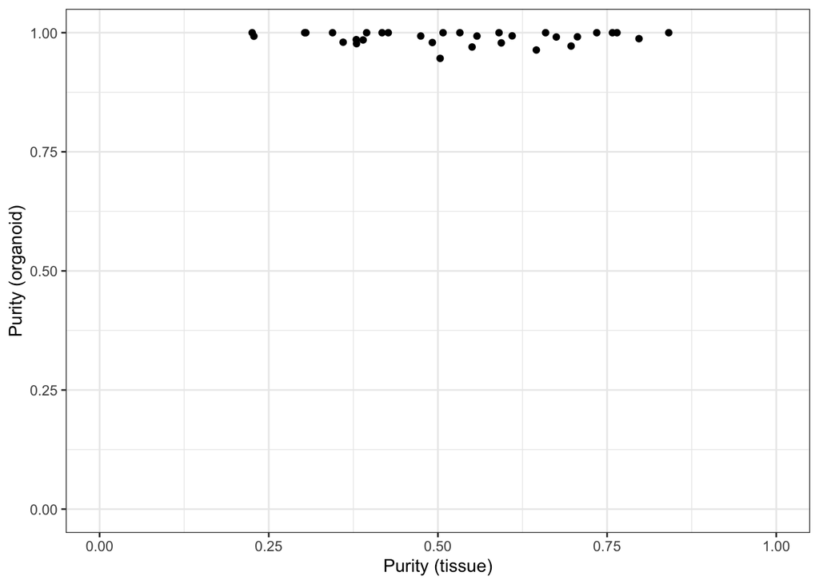

```r
df.ascatAnno %>%
  dplyr::select(case_id, specimen_source, Purity) %>%
  pivot_wider(names_from = specimen_source, values_from = Purity) %>%
  ggplot(aes(x = tissue, y = organoid)) + theme_bw() +
  geom_point() + xlim(0,1) + ylim(0,1) +
  labs(x = 'Purity (tissue)', y = 'Purity (organoid)')
```

```r
ggsave(filename = 'Results/OrganoidsOAC_concordancePurity.pdf')
# Wilcox test comparing purity in PDO vs tissue (for some reason)
print(paste0('Median Purity for organoids = ',median(df.ascatAnno$Purity[df.ascatAnno$specimen_source == 'organoid'], na.rm = TRUE)))
```

```
## [1] "Median Purity for organoids = 1"
```

```r
print(paste0('Median Purity for tissues = ',round(median(df.ascatAnno$Purity[df.ascatAnno$specimen_source == 'tissue'], na.rm = TRUE),4)))
```

```
## [1] "Median Purity for tissues = 0.52"
```

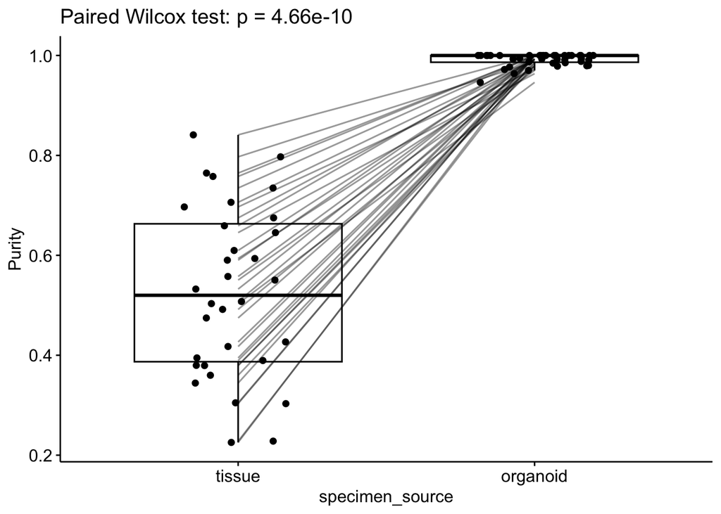

```r
df.ascatAnno %>%
  dplyr::select(case_id, specimen_source, Purity) %>%
  pivot_wider(names_from = specimen_source, values_from = Purity) %>%
  dplyr::filter(!is.na(tissue) & !is.na(organoid)) -> df.ascatAnno_paired
wilcox.test(x = df.ascatAnno_paired$tissue, y = df.ascatAnno_paired$organoid, paired = TRUE) -> wilcox.test_pairedPurity
ggboxplot(df.ascatAnno, x = 'specimen_source', y = 'Purity', add = 'jitter') +
  geom_line(aes(group = case_id), alpha = .4) +
  ggtitle(paste0('Paired Wilcox test: p = ',signif(wilcox.test_pairedPurity$p.value,3)))
```

```r
ggsave(filename = 'Results/OrganoidsOAC_Purity_PDOvsTissue.pdf')
```

## 2.3 HRD index score

We can also calculate the HRD Myriad index score, using the scarHRD R package. Here, we are using this primarily as a generic measure of chromosomal instability, since its association with HRD pan-cancer and with oesophageal adenocarcinoma itself is debatable.

For this we require the Caveman output (stored in the files.caveman object) and sample statistics information for ploidy normalisation (stored in the files.ploidy object).

The first step is input creation, where we extract the following information for each sample:

- SampleID
- Chromosome, Start position, and End position
- Probe count (unknown here)
- Total copy number, and Minor (A) and Major (B) copy number
- Ploidy and Contamination

```r
# We must start by generating scarHRD info, which we can store.
for (i in 1:length(files.caveman)) {

  cave.i <- read.csv(files.caveman[i])
  caveInfo.i <- read.delim(files.ploidy[i], header = FALSE, sep = ' ')
  sequence_id.i <- strsplit(strsplit(files.caveman[i],split='/')[[1]][3],split='_vs_')[[1]][1]

  input.i <- data.frame(
    SampleID = sequence_id.i,
    Chromosome = as.numeric(cave.i$Chromosome),
    Start_position = cave.i$Start,
    End_position = cave.i$End,
    num_probes = NA,
    total_cn = cave.i$Total_CN,
    A_cn = cave.i$Minor_CN,
    B_cn = cave.i$Total_CN - cave.i$Minor_CN,
    ploidy = caveInfo.i$V2[caveInfo.i$V1 == 'Ploidy'],
    contamination = caveInfo.i$V2[caveInfo.i$V1 == 'NormalContamination']
  )

  input.i <- input.i %>% filter(!is.na(Chromosome)) # remove regions outside of chromosomes 1-22
  write.table(input.i, file = paste0('Results/scarHRD/input/scarHRD_input_',sequence_id.i,'.txt'),
              sep='\t')

}
```

Now that we have generated input files, we can apply the scar_score() function to read htem in and calculate the respective HRD index score.

```r
files.scarHRD_input <- list.files(path = 'Results/scarHRD/input', full.names = TRUE, recursive = TRUE)

df.scarHRD <- data.frame()
for (file in files.scarHRD_input) {
  scarHRD.i <- scar_score(file, reference = 'grch37', output = 'Results/scarHRD/output') %>%
    as.data.frame
  scarHRD.i$sequence_id <- strsplit(
    strsplit(strsplit(file,split='/')[[1]][4],split='input_')[[1]][2],split='.txt')[[1]][1]
  df.scarHRD <- rbind(df.scarHRD, scarHRD.i)
}
```

[output not shown]

[output cut: 27 more lines]

[output not shown]

Now we can compare HRD index scores across organoids and tissues to check if chromosomal instability is retained.

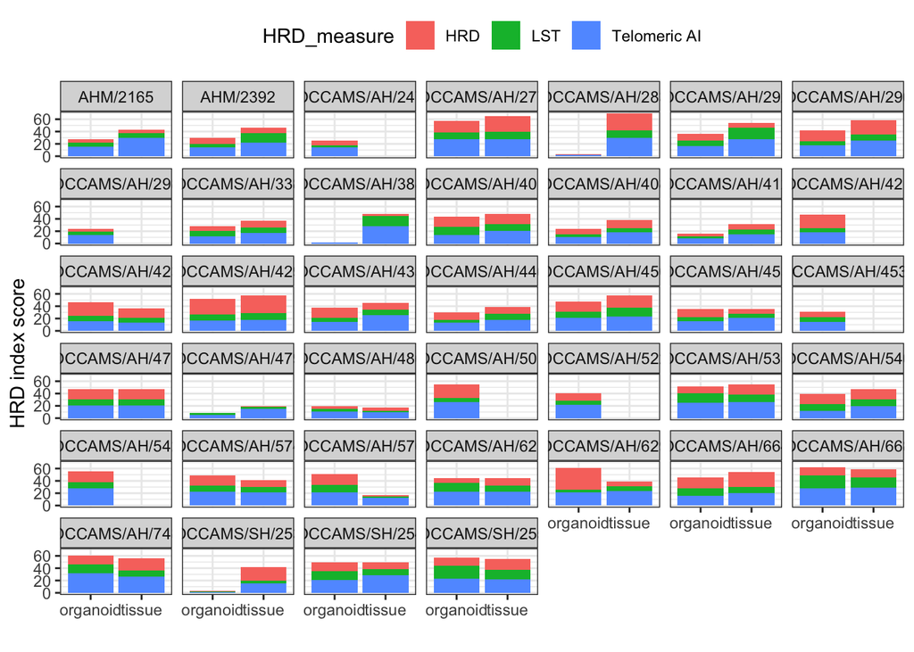

```r
# Add metadata
df.scarHRD <- merge(x = df.scarHRD, y = meta.wgs[,c('sequence_id','case_id','specimen_source')])

# Plot HRD index score formation per sample
df.scarHRD %>%
  dplyr::select(-`HRD-sum`) %>%
  pivot_longer(cols = c(HRD, `Telomeric AI`, LST), names_to = 'HRD_measure', values_to = 'score') %>%
  ggplot(aes(x = specimen_source, y = score, fill = HRD_measure)) + theme_bw() +
  geom_bar(stat = 'identity') +
  theme(legend.position = 'top') +
  labs(x='',y = 'HRD index score') +
  facet_wrap(~case_id)
```

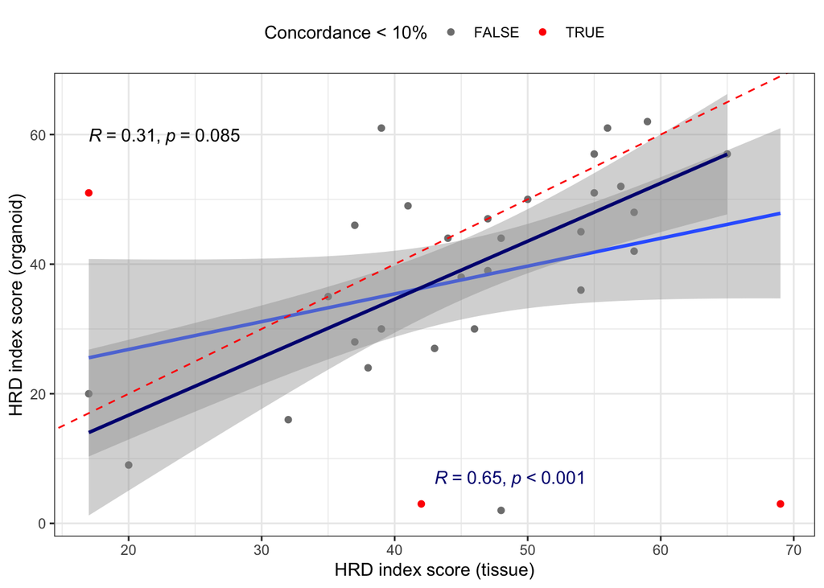

```r
# Correlate full HRD score across matched tissue/organoid pairs
df.scarHRD %>%
  mutate(`Concordance < 10%` = case_id %in% c('OCCAMS/SH/253','OCCAMS/AH/576','OCCAMS/AH/283')) %>%
  # dplyr::filter(`Concordance < 10%` == FALSE) %>%
  dplyr::select(case_id, specimen_source, `HRD-sum`, `Concordance < 10%`) %>%
  pivot_wider(names_from = specimen_source, values_from = `HRD-sum`) -> df.scarHRD_compare
ggplot(df.scarHRD_compare, aes(x = tissue, y = organoid)) +
  theme_bw() + geom_point(aes(color = `Concordance < 10%`)) + geom_smooth(method = 'lm') + stat_cor(p.accuracy = 0.001) +
  geom_smooth(data = df.scarHRD_compare[df.scarHRD_compare$`Concordance < 10%` == FALSE,], method = 'lm', color = 'navy') +
  stat_cor(data = df.scarHRD_compare[df.scarHRD_compare$`Concordance < 10%` == FALSE,], color = 'navy',
           label.x.npc = 'centre', label.y.npc = 'bottom', p.accuracy = 0.001) +
  geom_abline(col = 'red', linetype = 'dashed', slope = 1, intercept = 0) +
  theme(legend.position = 'top') +
  scale_color_manual(values = c('gray50','red')) +
  labs(x = 'HRD index score (tissue)', y = 'HRD index score (organoid)')
```

```r
ggsave(filename = 'Results/OrganoidsOAC_concordanceHRDscore.pdf')
```

## 2.4 Mutational signatures

Finally, we fit mutational signatures to the full SNV profiles of each sample. We will compare the concordance across these signatures, with specific note of SBS17a/b. These signatures were extracted using SigProfiler:

- SBS1 (ageing)
- SBS2 (APOBEC)
- SBS5 (ageing)
- SBS8 (unknown)
- SBS13 (APOBEC)
- SBS17a (unknown - OAC-prevalent)
- SBS17b (unknown - OAC-prevalent)
- SBS18 (ROS species)
- SBS31 (platinum chemotherapy)
- SBS35 (platinum chemotherapy)
- SBS40 (ageing)
- SBS93 (unknown)

This analysis is conducted on the full set of SNVs, so the first step is to load in all VCFs, which can then be processed and prepared for fitting using the deconstructSigs R package.

```r
# Load VCF files, and subset for those also profiled in VEP
files.vcf <- list.files(path = 'Data/strelka', pattern = '.vcf$', recursive = TRUE, full.names = TRUE)
files.vcf <- files.vcf[vep.files_include]

vcfs.all <- data.frame()
for (vcf in files.vcf) {

  # 1. Load data
  vcf.i <- read.vcfR(vcf, verbose = FALSE)@fix %>% as.data.frame

  # 2. Extract depth and VAF (will be useful going forward)
  vcf.i$DEPTH <- NA
  vcf.i$VAF <- NA

  if (grepl(pattern = '.snp.pass.vcf',vcf)) {
    index.depth <- which(grepl(pattern = 'Depth', strsplit(vcf.i$INFO[1],split=';')[[1]]))
    vcf.i$DEPTH <- sapply(vcf.i$INFO, function(x) as.numeric(strsplit(
      strsplit(x,split=';')[[1]][index.depth],split='=')[[1]][2]))

    index.vaf <- which(grepl(pattern = 'VariantAlleleFrequency', strsplit(vcf.i$INFO[1],split=';')[[1]]))
    vcf.i$VAF <- sapply(vcf.i$INFO, function(x) as.numeric(strsplit(
      strsplit(x,split=';')[[1]][index.vaf],split='=')[[1]][2]))
  }

  # 3. Add sequence_id
  vcf.i$sequence_id <- strsplit(strsplit(vcf, split='/')[[1]][3], split='_vs_')[[1]][1]

  # 4. Save output
  vcfs.all <- rbind(vcfs.all, vcf.i[,c('CHROM','POS','REF','ALT','DEPTH','VAF','sequence_id')])

}

# Generate deconstructSigs input
vcfs.all <- vcfs.all %>% filter(CHROM %in% paste0('chr',1:22))
vcfs.all$POS <- vcfs.all$POS %>% as.numeric

input.deconstruct_sigs <- mut.to.sigs.input(
  mut.ref = vcfs.all,
  sample.id = 'sequence_id',
  chr = 'CHROM',
  pos = 'POS',
  ref = 'REF',
  alt = 'ALT',
  bsg = BSgenome.Hsapiens.UCSC.hg19
)
```

We can now fit the twelve pre-identified signatures in deconstructSigs, which applies a modified linear regression model.

```r
# Prepare matrix of established signatures (GRCh37, v3.3.1)
sigs.hg37 <- read.table('Results/COSMIC_v3.3.1_SBS_GRCh37.txt', header = TRUE, row.names = 1)
sigs.hg37 <- as.data.frame(t(sigs.hg37))
sigs.hg37 <- sigs.hg37[,colnames(signatures.cosmic)] # reorders columns to fit deconstructSigs default

# Establish extracted signatures
sigs.extracted <- paste0('SBS',c(1,2,5,8,13,'17a','17b',18,31,35,40,93))

# Run deconstructSigs
sigs.extracted_complete <- data.frame()

for (sample in rownames(input.deconstruct_sigs)) {

  sigs.i <- whichSignatures(tumor.ref = input.deconstruct_sigs,
                            signatures.ref = sigs.hg37[sigs.extracted,],
                            sample.id = sample,
                            tri.counts.method = 'default',
                            contexts.needed = TRUE,
                            signature.cutoff = 0.02)
  sigs.i$weights$SBS_unknown <- sigs.i$unknown
  sigs.extracted_complete <- rbind(sigs.extracted_complete, sigs.i$weights)

}
```

For a starters, we can compare the overall signature profiles and calculate concordance across signatures within tissue/organoid pairs

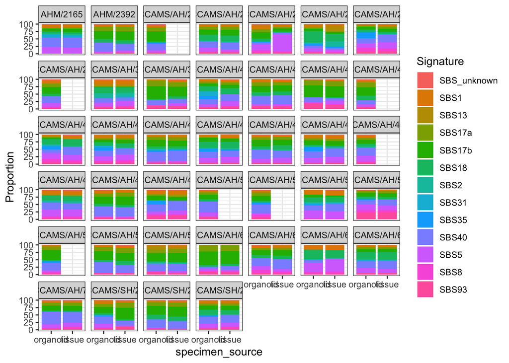

```r
# Add sequence_id column and merge with metadata
sigs.extracted_complete$sequence_id <- rownames(sigs.extracted_complete)
sigs.extracted_complete <- merge(x = sigs.extracted_complete,
                                 y = meta.wgs[,c('sequence_id','case_id','specimen_source')])
write.csv(sigs.extracted_complete, file = 'Results/OrganoidsOAC_SBSsignatures.csv')

# Plot full signature profiles
sigs.extracted_complete %>%
  pivot_longer(cols = c(SBS1,SBS2,SBS5,SBS8,SBS13,SBS17a,SBS17b,SBS18,SBS31,SBS35,SBS40,SBS93,SBS_unknown), names_to = 'Signature', values_to = 'Proportion') %>%
  mutate(Proportion = 100*Proportion) %>%
  ggplot(aes(x = specimen_source, y = Proportion, fill = Signature)) + theme_bw() +
  geom_bar(stat = 'identity') + facet_wrap(~case_id)
```

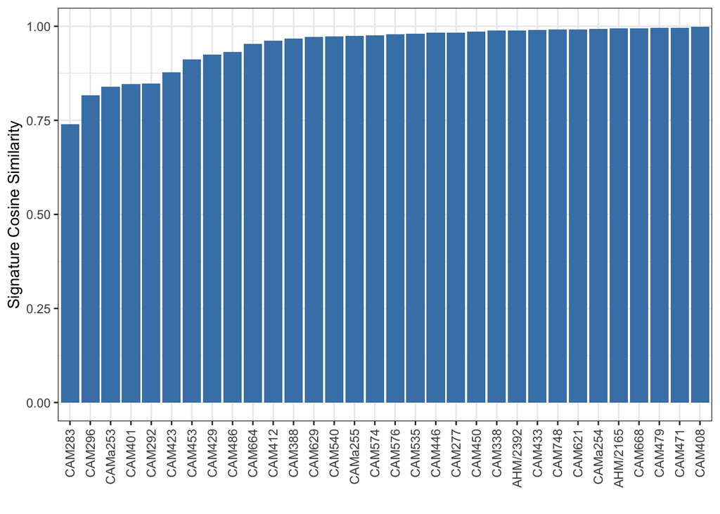

```r
write.csv(sigs.extracted_complete, file = 'Results/OrganoidsOAC_SignatureContributions.csv')

# Calculate cosine similarity, initially by separating sigs.extracted complete into organoid and tissue profiles
sigs.tissue <- sigs.extracted_complete %>% filter(specimen_source == 'tissue')
sigs.organoid <- sigs.extracted_complete %>% filter(specimen_source == 'organoid')

joint_cases <- intersect(sigs.tissue$case_id, sigs.organoid$case_id)
cosineSims <- c()

for (case in joint_cases) {

  tissue.sig <- sigs.tissue[which(sigs.tissue$case_id == case), grepl(pattern = 'SBS',names(sigs.tissue))]
  organoid.sig <- sigs.organoid[which(sigs.organoid$case_id == case), grepl(pattern = 'SBS',names(sigs.organoid))]

  cosineSim.i <- cosine(as.numeric(tissue.sig), as.numeric(organoid.sig))[1,1]
  cosineSims <- c(cosineSims, cosineSim.i)

}

# Order cosine similarities for plotting purposes
cosineSims <- data.frame(cosineSims, case = joint_cases)
cosineSims <- cosineSims %>% arrange(cosineSims)
cosineSims$case <- sapply(cosineSims$case, function(x)
  str_replace_all(x, c(`OCCAMS/AH/` = 'CAM', `OCCAMS/SH/` = 'CAMa')))
cosineSims$case <- factor(cosineSims$case, levels= cosineSims$case)

ggplot(cosineSims, aes(x = case, y = cosineSims)) +
  theme_bw() + geom_bar(stat = 'identity', fill = 'steelblue') +
  theme(axis.text.x = element_text(angle = 90, vjust = 0.5, hjust=1)) +
  labs(x = '', y = 'Signature Cosine Similarity')
```

```r
ggsave(filename = 'Results/OrganoidsOAC_SignatureCosineSimilarity.pdf', height = 4)
print(summary(cosineSims$cosineSims))
```

```
##    Min. 1st Qu.  Median    Mean 3rd Qu.    Max.
##  0.7391  0.9295  0.9776  0.9484  0.9905  0.9991
```

We can also try to summarise the overall signature profiles in a heatmap, clustered to match oragnoid-tissue pairs.

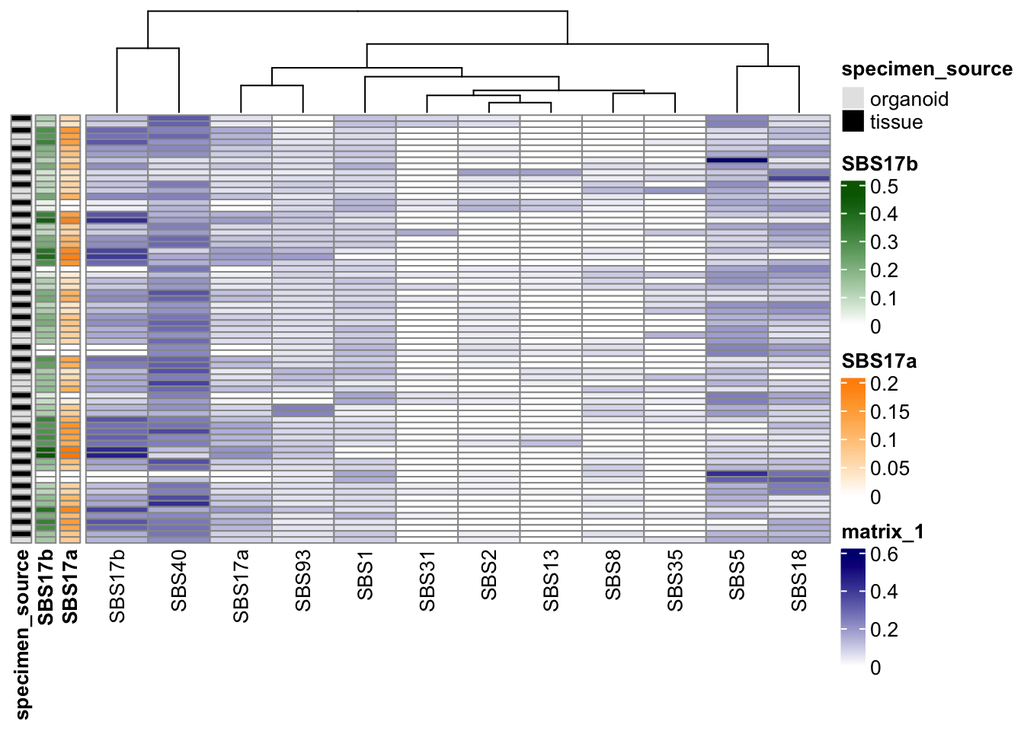

```r
## Compare matched tissues/organoids (use sigs.extracted_complete)
sigs.complete <- sigs.extracted_complete

# Start by just plotting them by patient
sigs.complete <- sigs.complete %>% arrange(case_id, desc(specimen_source))
rownames(sigs.complete) <- sigs.complete$sequence_id
sigs.ann <- sigs.complete[,c('SBS17a','SBS17b','specimen_source')]

cols_scale <- colorRampPalette(colors = c('white','navy'))(1000)
ann_colors <- list(
  specimen_source = c(organoid = 'gray90', tissue = 'black'),
  SBS17a = colorRampPalette(c('white','darkorange'))(100),
  SBS17b = colorRampPalette(c('white','darkgreen'))(100)
)

# pdf('Results/OrganoidsOAC_SignatureHeatmap.pdf')
pheatmap(sigs.complete[,2:13],
         cluster_rows = FALSE, annotation_row = sigs.ann, annotation_colors = ann_colors,
         show_rownames = FALSE, color = cols_scale)
```

```r
# dev.off()
```

We shall do a direct comparison of Signature 17 and save these for oncoplot annotation

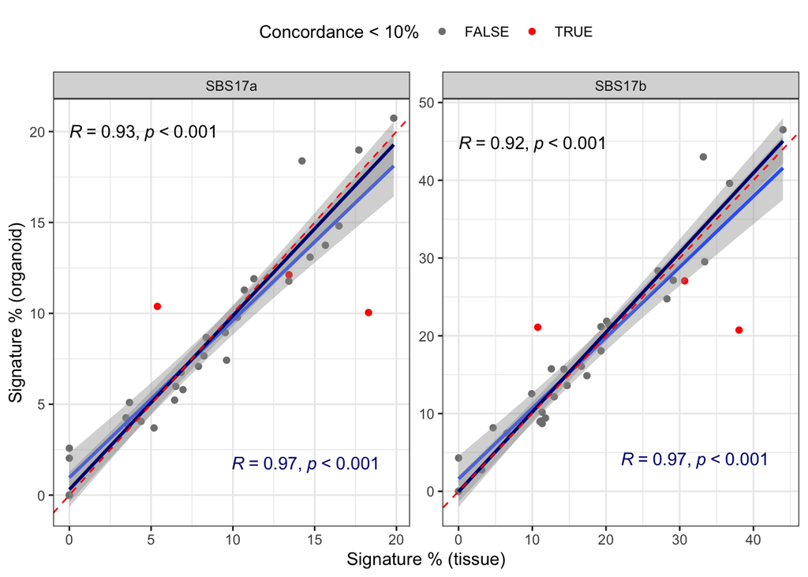

```r
# Correlation of Signature 17 between tissues and organoids
sigs.extracted_complete %>%
  mutate(`Concordance < 10%` = case_id %in% c('OCCAMS/SH/253','OCCAMS/AH/576','OCCAMS/AH/283')) %>%
  dplyr::select(case_id, specimen_source, `Concordance < 10%`, SBS17a, SBS17b) %>%
  pivot_longer(cols = c(SBS17a, SBS17b), names_to = 'Sig17', values_to = 'Proportion') %>%
  mutate(Proportion = 100 * Proportion) %>%
  pivot_wider(names_from = specimen_source, values_from = Proportion) -> df.sig17_compare

ggplot(df.sig17_compare, aes(x = tissue, y = organoid)) + theme_bw() +
  geom_point(aes(color = `Concordance < 10%`)) + geom_smooth(method = 'lm') + stat_cor(p.accuracy = 0.001) +
  geom_smooth(data = df.sig17_compare[df.sig17_compare$`Concordance < 10%` == FALSE, ], method = 'lm', color = 'navy') +
  stat_cor(data = df.sig17_compare[df.sig17_compare$`Concordance < 10%` == FALSE, ], color = 'navy',
           label.x.npc =  'centre', label.y.npc = 'bottom', p.accuracy = 0.001) +
  geom_abline(col = 'red', linetype = 'dashed', slope = 1, intercept = 0) +
  scale_color_manual(values = c('gray50','red')) +
  theme(legend.position = 'top') +
  labs(x = 'Signature % (tissue)', y = 'Signature % (organoid)') +
  facet_wrap(~Sig17, scales = 'free')
```

```r
ggsave(filename = 'Results/OrganoidsOAC_concordanceSignature17.pdf', height = 5)
# Save total Signature 17 contribition
df.sig17 <- data.frame(
  sequence_id = sigs.extracted_complete$sequence_id,
  case_id = sigs.extracted_complete$case_id,
  specimen_source = sigs.extracted_complete$specimen_source,
  SBS17 = sigs.extracted_complete$SBS17a + sigs.extracted_complete$SBS17b
)
```

As one final point, let’s combine our signature results with those from our gastric and BO organoids, to see how signature contributions are changing across stages.

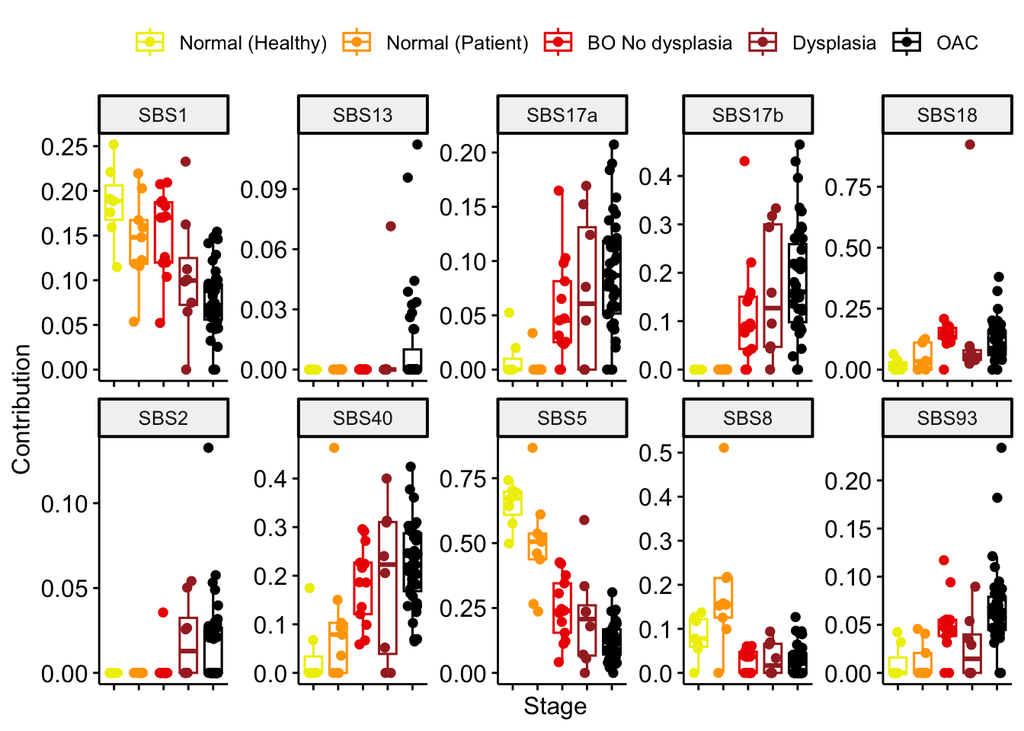

```r
# Fix OAC signatures
sigs.oac <- sigs.extracted_complete %>%
  filter(specimen_source == 'organoid') %>% mutate(Stage = 'OAC') %>%
  dplyr::select(-c(case_id, specimen_source, SBS_unknown, SBS31, SBS35)) %>%
  pivot_longer(cols = -c(sequence_id, Stage), names_to = 'Signature', values_to = 'Contribution')

# Add gastric/BO signatures
sigs.bo <- read.csv('~/Documents/Organoids/Manuscript_GeneralOrganoids/Scripts/OrganoidsGastricBE_WGS/Results/OrganoidsGastricBO_SignatureContributions.csv',
                    row.names = 1) %>%
  dplyr::filter(`Organoid.or.Tissue` == 'Organoids') %>%
  mutate(Stage = sapply(Patient.ID, function(x) strsplit(x,split='_')[[1]][2])) %>%
  dplyr::select(-c(Patient.ID, Organoid.or.Tissue, SBS_unknown)) %>%
  pivot_longer(cols = -c(sequence_id, Stage), names_to = 'Signature', values_to = 'Contribution')

sigs <- rbind(sigs.oac, sigs.bo) %>%
  mutate(Stage = factor(Stage, levels = c('Normal (Healthy)','Normal (Patient)','BO No dysplasia','Dysplasia','OAC')))
ggboxplot(sigs, x = 'Stage', y = 'Contribution', color = 'Stage', add = 'jitter') +
  facet_wrap(~Signature, scales = 'free', nrow = 2) +
  scale_color_manual(values = c('yellow2','orange','red2','brown','black')) +
  theme(axis.text.x = element_blank(), legend.title = element_blank())
```

```r
ggsave(filename = 'Results/OrganoidsOAC_GastricBO_signatureComparisons.pdf')
```

# 3 Oncoplot

Now that we have collated the relevant driver mutations, as well as genomic features for annotation, we can collate our oncoplot describing the relations between tissues and their respective organoids.

## 3.1 Prepare driver data

The oncoplot will be generated using the oncoPrint() function from the ComplexHeatmaps R package. Therefore, it must be structured in their style.

```r
# Group by sequence_id+Gene to generate a single 'mutationLabel', with mutations separated by ';'
muts.oac_plot <- muts.oac %>%
  group_by(occams.ID, sequence_id, specimen_source, Gene, mutationType) %>%
  summarise() %>%
  group_by(occams.ID, sequence_id, specimen_source, Gene) %>%
  summarise(mutationLabel = paste(mutationType, collapse=';')) %>%
  mutate(mutationLabel = paste0(mutationLabel,';'))
```

```
## `summarise()` has regrouped the output.
## `summarise()` has regrouped the output.
## ℹ Summaries were computed grouped by occams.ID, sequence_id, specimen_source,
##   Gene, and mutationType.
## ℹ Output is grouped by occams.ID, sequence_id, specimen_source, and Gene.
## ℹ Use `summarise(.groups = "drop_last")` to silence this message.
## ℹ Use `summarise(.by = c(occams.ID, sequence_id, specimen_source, Gene,
##   mutationType))` for per-operation grouping (`?dplyr::dplyr_by`) instead.
```

```r
# Pivot alterations out to generate a matrix
muts.oac_plot <- muts.oac_plot[,c('sequence_id','Gene','mutationLabel')] %>%
  pivot_wider(names_from = sequence_id, values_from = mutationLabel) %>%
  column_to_rownames(var = 'Gene') %>% as.matrix
muts.oac_plot[is.na(muts.oac_plot)] <- ''

# One sample (1631_WTSI-OESO_196_a_DNA) harboured no driver alterations (only 2x 3'-UTR variants), and therefore is missing from this plot. We can add this sample manually here
muts.oac_plot <- cbind(muts.oac_plot, '1631_WTSI-OESO_196_a_DNA' = "")
```

## 3.2 Prepare annotation information

Here, we will collate the genomic features we have profiled previously (TMB, ploidy/purity, HRD index score, signatures), as well as clinical metadata.

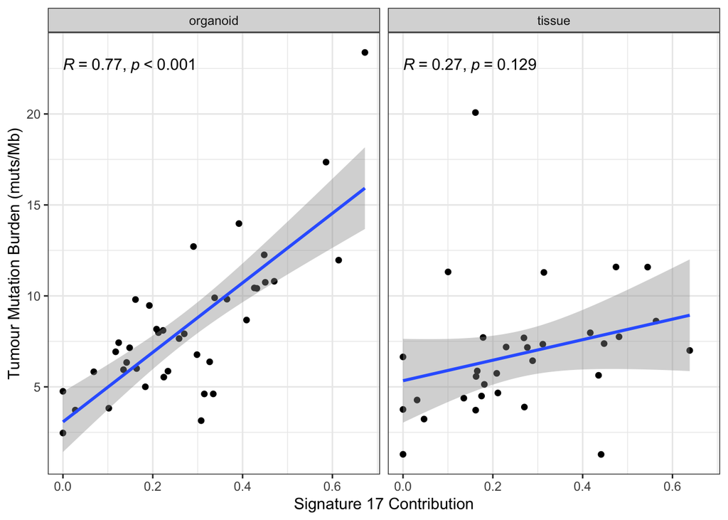

```r
# Collate genomic features we have collected here. Note that for the Birmingham organoids we are restricted to TMB and ploidy
muts.oac_ann <- df.ascatAnno[,c('sequence_id','case_id','specimen_source','Ploidy','Purity')] # start with ploidy/purity
muts.oac_ann <- merge(x = muts.oac_ann, y = df.tmb, all.x = TRUE) # add TMB
muts.oac_ann <- merge(x = muts.oac_ann, y = df.scarHRD[,c('sequence_id','case_id','specimen_source','HRD-sum')], all.x = TRUE) # add HRD index score
muts.oac_ann <- merge(x = muts.oac_ann, y = df.sig17, all.x = TRUE) # add SBS17

# Add SBS18 and SBS40 - this will be for the summary plot
muts.oac_ann <- merge(x = muts.oac_ann, y = sigs.extracted_complete[,c('sequence_id','SBS18','SBS40')], all.x = TRUE)

# # Now we can add relevant clinical information
# #   Note that we will have to add the Birmingham organoids, and the AHM OAC organoids, manually
# occams.clin <- read_excel('Data/query_standard_cohort_2025-03-25_16-27-46.xlsx')
# occams.clin <- occams.clin[,c(1:3,12)]
# names(occams.clin) <- c('case_id','Sex','Age','Stage')
# occams.clin <- occams.clin %>% filter(!duplicated(case_id))
#
# # Alter invasion labels in stage data
# occams.clin$Stage[occams.clin$Stage == 'tumour_invades_adventitia'] <- 'T3b'
# occams.clin$Stage[occams.clin$Stage == 'tumour_invades_muscularis_propria'] <- 'T2'
# occams.clin$Stage <- factor(occams.clin$Stage, levels = sort(unique(occams.clin$Stage)))

# Add chemo, surgical T-stage, and histopath. grading
occams.grad <- read_excel('Data/Copy of Org_Clinical_demo_For_DJ.xlsx') %>%
  dplyr::filter(!is.na(`Chemotherapy regimen`))

# Repeat OCCAMS/AH/453 for staging lap
occams.grad <- data.frame(
  ID=c(occams.grad$ID,'OCCAMS/AH/453L'),
  Age=c(occams.grad$Age,69), Sex=c(occams.grad$Sex,'M'), `Surgical TNM`=c(occams.grad$`Surgical TNM`,'T3N1M0'),
  `Chemotherapy regimen`=c(occams.grad$`Chemotherapy regimen`,'ECX'),
  `Histopathological grading`=c(occams.grad$`Histopathological grading`,'Poor')
)
names(occams.grad) <- c('ID','Age','Sex','Surgical TNM','Chemotherapy regimen','Histopathological grading')

occams.grad$`Histopathological grading`[occams.grad$`Histopathological grading` == 'Moderate '] <- 'Moderate'
occams.grad$Stage <- sapply(occams.grad$`Surgical TNM`, function(x) strsplit(x,split='N')[[1]][1])
occams.grad$Stage[occams.grad$Stage == '-'] <- 'Missing'

# occams.clin <- merge(x = occams.clin, y = occams.grad[,c('ID','Age','Sex','Stage','Chemotherapy regimen','Histopathological grading')],
#                      by.x = 'case_id', by.y = 'ID', all.x = TRUE)
#
# # Add info for missing cases (from attached file)
# print(occams.clin$case_id[is.na(occams.clin$`Chemotherapy regimen`)]) # to show order
# occams.clin$`Chemotherapy regimen`[is.na(occams.clin$`Chemotherapy regimen`)] <-
#   c('ECX','ECX','ECF','None','ECX',NA)
# occams.clin$`Histopathological grading`[is.na(occams.clin$`Histopathological grading`)] <-
#   c('Moderate','Unknown','Moderate','Poor','Poor',NA)

# Merge with genomic features
muts.oac_ann <- merge(x = muts.oac_ann, y = occams.grad[,c('ID','Age','Sex','Stage','Chemotherapy regimen','Histopathological grading')],
                      all.x = TRUE,
                      by.x = 'case_id', by.y = 'ID')

# Manually add AHM information on sex, age, and stage [TO BE DONE]

# # Manually add OC/AH/748
# muts.oac_ann$Sex[muts.oac_ann$case_id == 'OCCAMS/AH/748'] <- 'male'
# muts.oac_ann$Age[muts.oac_ann$case_id == 'OCCAMS/AH/748'] <- 72
# muts.oac_ann$Stage[muts.oac_ann$case_id == 'OCCAMS/AH/748'] <- 'T3'
# muts.oac_ann$`Chemotherapy regimen`[muts.oac_ann$case_id == 'OCCAMS/AH/748'] <- 'None'
# muts.oac_ann$`Histopathological grading`[muts.oac_ann$case_id == 'OCCAMS/AH/748'] <- 'No pathology'

# Manually add Birmingham organoids
# muts.oac_ann$Sex[match(c('OESO/117','OESO/146'), muts.oac_ann$case_id)] <- c('male','male')
# muts.oac_ann$Age[match(c('OESO/117','OESO/146'), muts.oac_ann$case_id)] <- c(61,73)
# muts.oac_ann$Stage[match(c('OESO/117','OESO/146'), muts.oac_ann$case_id)] <- c('T3b','T1b')
# muts.oac_ann$`Chemotherapy regimen`[match(c('OESO/117','OESO/146'), muts.oac_ann$case_id)] <- c('None','None')
muts.oac_ann$`Histopathological grading`[match(c('OESO/117','OESO/146'), muts.oac_ann$case_id)] <- c('Unknown','Unknown')

# Manually add AHM organoids
muts.oac_ann$Sex[muts.oac_ann$case_id == 'AHM/2165'] <- 'M'
muts.oac_ann$Age[muts.oac_ann$case_id == 'AHM/2165'] <- 77
muts.oac_ann$Stage[muts.oac_ann$case_id == 'AHM/2165'] <- 'T1'
muts.oac_ann$`Chemotherapy regimen`[muts.oac_ann$case_id == 'AHM/2165'] <- 'None'
muts.oac_ann$`Histopathological grading`[muts.oac_ann$case_id == 'AHM/2165'] <- 'No pathology'

muts.oac_ann$Sex[muts.oac_ann$case_id == 'AHM/2392'] <- 'F'
muts.oac_ann$Age[muts.oac_ann$case_id == 'AHM/2392'] <- 87
muts.oac_ann$Stage[muts.oac_ann$case_id == 'AHM/2392'] <- 'T1'
muts.oac_ann$`Chemotherapy regimen`[muts.oac_ann$case_id == 'AHM/2392'] <- 'None'
muts.oac_ann$`Histopathological grading`[muts.oac_ann$case_id == 'AHM/2392'] <- 'No pathology'

# Fix up annotation data, and reorder by stage, case ID, and specimen source for plotting
#
muts.oac_ann$Age <- as.numeric(muts.oac_ann$Age)

muts.oac_ann <- muts.oac_ann %>% arrange(Stage, case_id, desc(specimen_source))

# For the sake of curiosity (given reporting in Secrier et al. 2016), check relationship between TMB and SBS17 contribution
ggplot(muts.oac_ann, aes(x = SBS17, y = TMB)) + theme_bw() +
  geom_point() + geom_smooth(method = 'lm') + stat_cor(p.accuracy = 0.001) +
  labs(x = 'Signature 17 Contribution', y = 'Tumour Mutation Burden (muts/Mb)') +
  facet_wrap(~specimen_source)
```

```r
ggsave(filename = 'Results/OrganoidsOAC_TMBvsSig17.pdf', height = 5)
```

```r
# Reorder oncoplot data to reflect annotation shown here
muts.oac_plot <- muts.oac_plot[,muts.oac_ann$sequence_id]
```

## 3.3 Define plotting features for oncoPrint

```r
col.bars = c("Amplification" = "darkred", "Deletion" = "turquoise3",
        'frameshift_variant' = 'blue3', 'inframe_deletion' = 'orange3', 'inframe_insertion' = 'yellow3',
        'missense_variant' = 'red2', 'NMD_transcript_variant' = 'darkgreen', 'stop_gained' = 'purple3')

alter_fun = list(
  background = alter_graphic("rect", fill = "gray90"),
  Amplification = alter_graphic("rect", fill = col.bars["Amplification"]),
  Deletion = alter_graphic("rect", fill = col.bars["Deletion"]),
  # Loss = alter_graphic("rect", fill = col.bars["Loss"]),
  frameshift_variant = alter_graphic("rect", height = 0.33, fill = col.bars["frameshift_variant"]),
  inframe_deletion = alter_graphic("rect", height = 0.33, fill = col.bars["inframe_deletion"]),
  inframe_insertion = alter_graphic("rect", height = 0.33, fill = col.bars["inframe_insertion"]),
  missense_variant = alter_graphic("rect", height = 0.33, fill = col.bars["missense_variant"]),
  NMD_transcript_variant = alter_graphic("rect", height = 0.33, fill = col.bars["NMD_transcript_variant"]),
  stop_gained = alter_graphic("rect", height = 0.33, fill = col.bars["stop_gained"])
)
```

This can also include barplots to go on the right-hand annotation, which will be separated between organoids and tissues

```r
# Generate barplot of driver genes in tissues, which should include all possible driver genes and driver events
annoMut.tissue_init <- muts.oac %>%
  filter(specimen_source == 'tissue') %>%
  group_by(Gene, mutationType) %>% summarise(n = length(unique(sequence_id))) %>%
  pivot_wider(names_from = 'mutationType', values_from = n, values_fill = 0) %>%
  column_to_rownames(var = 'Gene') %>% as.matrix
```

```
## `summarise()` has regrouped the output.
## ℹ Summaries were computed grouped by Gene and mutationType.
## ℹ Output is grouped by Gene.
## ℹ Use `summarise(.groups = "drop_last")` to silence this message.
## ℹ Use `summarise(.by = c(Gene, mutationType))` for per-operation grouping
##   (`?dplyr::dplyr_by`) instead.
```

```r
annoMut.tissue <- rbind(annoMut.tissue_init,
                        matrix(0,nrow=nrow(muts.oac_plot)-nrow(annoMut.tissue_init),
                               ncol=ncol(annoMut.tissue_init)))
rownames(annoMut.tissue)[(nrow(annoMut.tissue_init)+1):nrow(muts.oac_plot)] <-
  unique(muts.oac$Gene)[!(unique(muts.oac$Gene) %in% rownames(annoMut.tissue))]
annoMut.tissue <- cbind(annoMut.tissue, 'inframe_insertion' = 0)

annoMut.tissue <- annoMut.tissue[,names(col.bars)]
annoMut.tissue <- annoMut.tissue[rownames(muts.oac_plot), ]

# Generate barplot of driver genes in organoids, which should include all possible driver genes and driver events
annoMut.organoid_init <- muts.oac %>%
  filter(specimen_source == 'organoid') %>%
  group_by(Gene, mutationType) %>% summarise(n = length(unique(sequence_id))) %>%
  pivot_wider(names_from = 'mutationType', values_from = n, values_fill = 0) %>%
  column_to_rownames(var = 'Gene') %>% as.matrix
```

```
## `summarise()` has regrouped the output.
## ℹ Summaries were computed grouped by Gene and mutationType.
## ℹ Output is grouped by Gene.
## ℹ Use `summarise(.groups = "drop_last")` to silence this message.
## ℹ Use `summarise(.by = c(Gene, mutationType))` for per-operation grouping
##   (`?dplyr::dplyr_by`) instead.
```

```r
annoMut.organoid <- rbind(annoMut.organoid_init,
                          matrix(0,nrow=nrow(muts.oac_plot)-nrow(annoMut.organoid_init),
                                 ncol=ncol(annoMut.organoid_init)))
rownames(annoMut.organoid)[(nrow(annoMut.organoid_init)+1):nrow(muts.oac_plot)] <-
  unique(muts.oac$Gene)[!(unique(muts.oac$Gene) %in% rownames(annoMut.organoid))]

annoMut.organoid <- annoMut.organoid[,names(col.bars)]
annoMut.organoid <- annoMut.organoid[rownames(muts.oac_plot), ]
```

And with that, we should be able to collate the final oncoplot…

```r
heatmap_legend_param = list(title = "Alterations", at = names(col), labels = names(col))

# Alter column names, for ease of reading. This involves 'OCCAMS/AH', being replace with 'CAM', and clarification of organoid or tumour
muts.oac_ann$column_name <- muts.oac_ann$case_id
muts.oac_ann$column_name[grepl(pattern = 'OCCAMS/AH', muts.oac_ann$column_name)] <- sapply(
  muts.oac_ann$case_id[grepl(pattern = 'OCCAMS/AH', muts.oac_ann$case_id)], function(x)
    paste0('CAM',strsplit(x,split='/')[[1]][3])
)
muts.oac_ann$column_name[grepl(pattern = 'OCCAMS/SH', muts.oac_ann$column_name)] <- sapply(
  muts.oac_ann$case_id[grepl(pattern = 'OCCAMS/SH', muts.oac_ann$case_id)], function(x)
    paste0('CAMa',strsplit(x,split='/')[[1]][3])
)
muts.oac_ann$column_name <- apply(muts.oac_ann, 1, function(x)
  paste(x['column_name'],toupper(substr(x['specimen_source'],1,1)),sep='_'))

colnames(muts.oac_plot) <- muts.oac_ann$column_name

# Change case where histopathological grading is 'Moderate '
muts.oac_ann$`Histopathological grading`[17] <- 'Moderate'

# Remove genes found in only one tissue/organoid
muts.oac_plot <- muts.oac_plot[apply(muts.oac_plot, 1, function(x) sum(x != '') > 1), ]

# Final oncoprint formation
pdf('Results/Oncoplot_OACtissuesOrganoids.pdf', width = 16, height = 12)
oncoPrint(muts.oac_plot,
          alter_fun = alter_fun, col = col.bars,
          column_split = data.frame(muts.oac_ann$Stage, muts.oac_ann$case_id),
          top_annotation = HeatmapAnnotation(
            cbar = anno_oncoprint_barplot(),
            Purity = anno_points(muts.oac_ann$Purity),
            Ploidy = anno_points(muts.oac_ann$Ploidy),
            `TMB (muts/Mb)` = anno_barplot(muts.oac_ann$TMB, bar_width = .8, gp = gpar(fill = 'purple4')),
            `Signature 17` = muts.oac_ann$SBS17,
            `HRD score` = muts.oac_ann$`HRD-sum`,
            `Age` = muts.oac_ann$Age,
            `Sex` = muts.oac_ann$Sex,
            `Histopathological Grading` = muts.oac_ann$`Histopathological grading`,
            `Chemotherapy` = muts.oac_ann$`Chemotherapy regimen`,
            `Tumour Stage` = muts.oac_ann$Stage,
            `Tissue/Organoid` = muts.oac_ann$specimen_source,
            col = list(cbar = col.bars,
                       `Tissue/Organoid` = c('tissue'='gray20','organoid'='gray90'),
                       `Sex` = c('M' = 'darkblue', 'F' = 'lightblue'),
                       `Tumour Stage` = c('T1' = 'yellow1','T1a' = 'yellow2','T1b' = 'yellow3',
                                          'T2' = 'orange',
                                          'T3' = 'red', 'T4a' = 'red3',
                                          'T4b' = 'brown', 'Missing' = 'grey'),
                       `Histopathological Grading` = c('Well' = 'pink', 'Moderate' = 'plum1', 'Poor' = 'mediumorchid4', 'Unknown' = 'gray85', 'No pathology' = 'gray25'),
                       `Chemotherapy` = c('CF' = 'lightblue1', 'ECF' = 'lightblue3', 'ECX' = 'navy', 'EOX' = 'aquamarine4', 'CX-Trastuzumab' = 'aquamarine3', 'FLOT' = 'pink3', 'None' = 'white', 'N/A' = 'gray85'),
                       `Signature 17` = colorRamp2(c(0,max(muts.oac_ann$SBS17, na.rm = TRUE)),
                                                          colors = c('white','green4')),
                       `HRD score` = colorRamp2(c(0,max(muts.oac_ann$`HRD-sum`, na.rm = TRUE)),
                                                       colors = c('white','pink3')),
                       `Age` = colorRamp2(c(50,max(muts.oac_ann$Age, na.rm = TRUE)),
                                                 colors = c('white','gold3'))
                       )
          ),
          right_annotation = rowAnnotation(
            Tissue = anno_barplot(annoMut.tissue, gp=gpar(fill = col.bars)),
            Organoid = anno_barplot(annoMut.organoid, gp=gpar(fill = col.bars))
          ),
          heatmap_legend_param = heatmap_legend_param,
          column_order = colnames(muts.oac_plot),
          show_column_names = TRUE)
```

```
## All mutation types: missense_variant, stop_gained, frameshift_variant,
## Amplification, NMD_transcript_variant, inframe_deletion, Deletion,
## inframe_insertion.
```

```
## `alter_fun` is assumed vectorizable. If it does not generate correct
## plot, please set `alter_fun_is_vectorized = FALSE` in `oncoPrint()`.
```

```r
dev.off()
```

```r
# Save annotation and coding mutation data
write.csv(muts.oac_ann, file = 'Results/Oncoplot_OAC_annotation.csv')
write.csv(muts.oac, file = 'Results/OrganoidsOAC_OACcodingAlterations.csv')

# Finally, let's report the frequencies of the key drivers in our OAC PDOs
muts.oac %>%
  filter(specimen_source == 'organoid') %>%
  group_by(occams.ID, Gene) %>% summarise() %>%
  group_by(Gene) %>% summarise(altered_PDO = n(), prop_altered_PDO = n()/sum(muts.oac_ann$specimen_source == 'organoid')) %>%
  arrange(desc(prop_altered_PDO))
```

```
## `summarise()` has regrouped the output.
## ℹ Summaries were computed grouped by occams.ID and Gene.
## ℹ Output is grouped by occams.ID.
## ℹ Use `summarise(.groups = "drop_last")` to silence this message.
## ℹ Use `summarise(.by = c(occams.ID, Gene))` for per-operation grouping
##   (`?dplyr::dplyr_by`) instead.
```

```
## # A tibble: 58 × 3
##    Gene   altered_PDO prop_altered_PDO
##    <chr>        <int>            <dbl>
##  1 TP53            30            0.732
##  2 ARID1A          10            0.244
##  3 MUC6             9            0.220
##  4 CDKN2A           8            0.195
##  5 KRAS             8            0.195
##  6 PIK3CA           7            0.171
##  7 LRRK2            6            0.146
##  8 MYC              6            0.146
##  9 CDK6             5            0.122
## 10 ERBB2            5            0.122
## # ℹ 48 more rows
```

```r
# Following sequence IDs
df.treated_PDOs <- data.frame(
  cam_ID = c('CAM574','CAM277','CAM408','CAM412','CAM501','OESO117','OESO146'),
  sequence_id = c('2126_WTSI-OESO_211_1pre','PD26661d','1631_WTSI-OESO_009_w6','1631_WTSI-OESO_040_1pre','1631_WTSI-OESO_165_1pre',
                  'HCM-SANG-0311-C15-B','HCM-SANG-0309-C15')
)

# Get TP53 status
df.tp53 <- muts.oac %>% dplyr::filter(Gene == 'TP53') %>% dplyr::select(sequence_id, mutationType) %>% rename(mutationType = 'TP53_status')
df.treated_PDOs <- merge(x = df.treated_PDOs, y = df.tp53, all.x = TRUE)
df.treated_PDOs$TP53_status[is.na(df.treated_PDOs$TP53_status)] <- 'no change'

# Get TMB, ploidy, purity, and SBS17
df.treated_PDOs <- merge(x = df.treated_PDOs, y = muts.oac_ann[,c('sequence_id','Ploidy','Purity','TMB','HRD-sum','SBS17')])

# Get copy numbers of KRAS
df.cnv_kras <- cnv.full %>% dplyr::filter(hgnc_symbol == 'KRAS') %>% dplyr::select(sequence_id, Total_CN) %>% rename(Total_CN = 'KRAS_copyNumber')
df.treated_PDOs <- merge(x = df.treated_PDOs, y = df.cnv_kras, all.x = TRUE)
df.treated_PDOs$KRAS_copyNumber[is.na(df.treated_PDOs$KRAS_copyNumber)] <- 'diploid'

# Get copy numbers of ERBB2
df.cnv_erbb2 <- cnv.full %>% dplyr::filter(hgnc_symbol == 'ERBB2') %>% dplyr::select(sequence_id, Total_CN) %>% rename(Total_CN = 'ERBB2_copyNumber')
df.treated_PDOs <- merge(x = df.treated_PDOs, y = df.cnv_erbb2, all.x = TRUE)
df.treated_PDOs$ERBB2_copyNumber[df.treated_PDOs$cam_ID == 'OESO146'] <- 13 # obtained here: https://cellmodelpassports.sanger.ac.uk/passports/SIDM01312
df.treated_PDOs$ERBB2_copyNumber[is.na(df.treated_PDOs$ERBB2_copyNumber)] <- 'diploid'

df.treated_PDOs <- df.treated_PDOs %>% dplyr::select(-sequence_id)
# df.treated_PDOs <- df.treated_PDOs[match(c('CAM574','CAM277','CAM408','CAM412','CAM501','OESO117','OESO146'), df.treated_PDOs$cam_ID), ]

write.csv(df.treated_PDOs, file = 'Results/TreatedPDOs_ClinicalInfo.csv')

# Simultaneously, I will retrieve the copy number alterations in PDOs treated with CDK4/6 inhibitors
cnv.full %>% dplyr::filter(specimen_source == 'organoid' & case_id %in% paste0('OCCAMS/AH/',c(277,401,535,429))) %>%
  dplyr::select(case_id, hgnc_symbol, Total_CN, Minor_CN, CNV) %>%
  mutate(case_id = sapply(case_id, function(x) paste0('CAM',strsplit(x,split='/')[[1]][3]))) -> cnv.full_cdk46i
write.csv(cnv.full_cdk46i, file = 'Results/OrganoidsOAC_treatedCDK46i_copyNumberAlterations.csv')
```

# 4 Concordance Analysis

The final step of this analysis is to demonstrate the level of concordance in mutation profiles between matched organoid/tissue pairs. This will be done using the full set of SNVs and indels contained within the ‘vcfs.all’ object used to calculate the mutational signatures. And since the variant allele frequencies were also saved, we can check how this is altered in organoids compared with tissues.

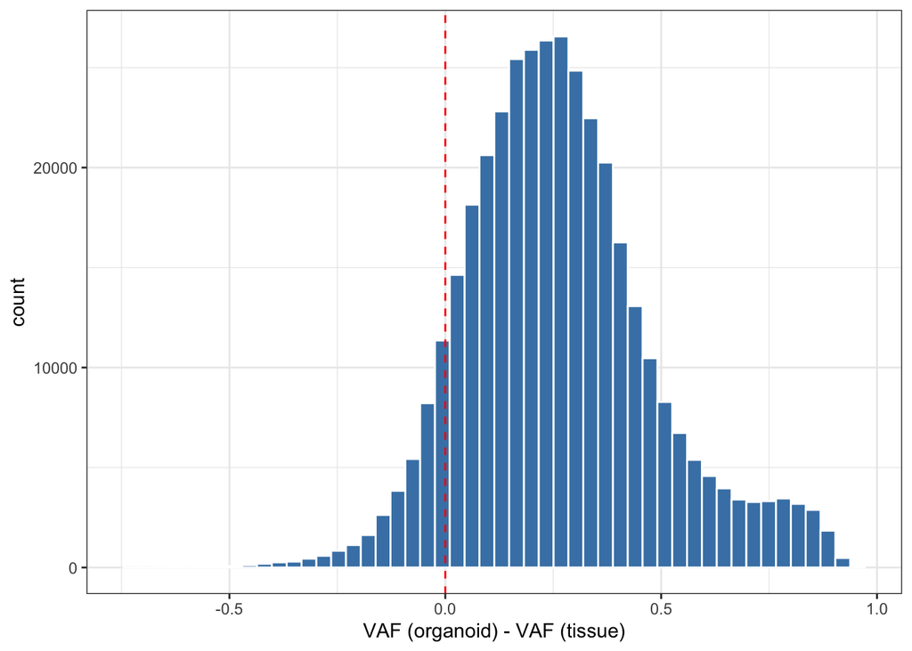

```r
# Add metadata
vcfs.full <- merge(x = vcfs.all, y = meta.wgs[,c('sequence_id','case_id','specimen_source')])

# This will only be relevant to SNVs, so we extract these
vcfs.full <- vcfs.full %>%
  filter(REF %in% c('A','C','T','G') &
           ALT %in% c('A','C','T','G'))

# Paired mutations can be identified via a specific mutationID containing case ID and mutation information, which is then pivoted out to compare VAFs
vcfs.full$POS <- as.character(vcfs.full$POS)
vcfs.full$MUTATION_ID <- apply(vcfs.full[,c(8,2:5)], 1, function(x) paste(x,collapse='_'))

vcfs.shared <- vcfs.full %>%
  dplyr::select(MUTATION_ID, specimen_source, VAF) %>%
  pivot_wider(names_from = specimen_source, values_from = VAF) %>%
  mutate(VAF_diff = organoid - tissue)
ggplot(vcfs.shared, aes(x = VAF_diff)) + theme_bw() +
  geom_histogram(bins = 50, fill = 'steelblue', color = 'white') +
  geom_vline(col = 'red', linetype = 'dashed', xintercept = 0) +
  xlab('VAF (organoid) - VAF (tissue)')
```

```r
ggsave(filename = 'Results/OrganoidsOAC_differencesVAF.pdf',
       width = 5, height = 5)
# Label mutations as Concordant, Organoid_only, or Tissue_only, add case_id and summarise counts of each
vcfs.shared$Label <- 'Concordant'
vcfs.shared$Label[is.na(vcfs.shared$tissue)] <- 'Organoid_only'
vcfs.shared$Label[is.na(vcfs.shared$organoid)] <- 'Tissue_only'

vcfs.shared$case_id <- sapply(vcfs.shared$MUTATION_ID, function(x) strsplit(x,split='_')[[1]][1])

muts.shared_summary <- vcfs.shared %>%
  group_by(case_id, Label) %>% summarise(n=n()) %>%
  mutate(case_id = sapply(case_id, function(x) str_replace_all(x, c(`OCCAMS/AH/` = 'CAM', `OCCAMS/SH/` = 'CAMa'))))
```

```
## `summarise()` has regrouped the output.
## ℹ Summaries were computed grouped by case_id and Label.
## ℹ Output is grouped by case_id.
## ℹ Use `summarise(.groups = "drop_last")` to silence this message.
## ℹ Use `summarise(.by = c(case_id, Label))` for per-operation grouping
##   (`?dplyr::dplyr_by`) instead.
```

```r
# Rank case_id by percentage of concordant mutations, and remove samples with no matched tissue
muts.concordant <-muts.shared_summary %>%
  pivot_wider(names_from = Label, values_from = n, values_fill = 0) %>%
  mutate(percentage_Concordant = Concordant/(Concordant + Organoid_only + Tissue_only)) %>%
  arrange(percentage_Concordant) %>%
  filter(percentage_Concordant > 0)

## print proportion of cases with >50% concordance, and those with <10% concordance
print(paste0('Proportion of cases with >50% concordance: ',
             sum(muts.concordant$percentage_Concordant > .5), '/',nrow(muts.concordant),
             ' = ', round(100 * mean(muts.concordant$percentage_Concordant > .5),2)))
```

```
## [1] "Proportion of cases with >50% concordance: 14/32 = 43.75"
```

```r
print('==== Case IDs with <10% concordance ====')
```

```
## [1] "==== Case IDs with <10% concordance ===="
```

```r
print(as.character(muts.concordant$case_id[muts.concordant$percentage_Concordant < .1]))
```

```
## [1] "CAMa253" "CAM283"  "CAM576"
```

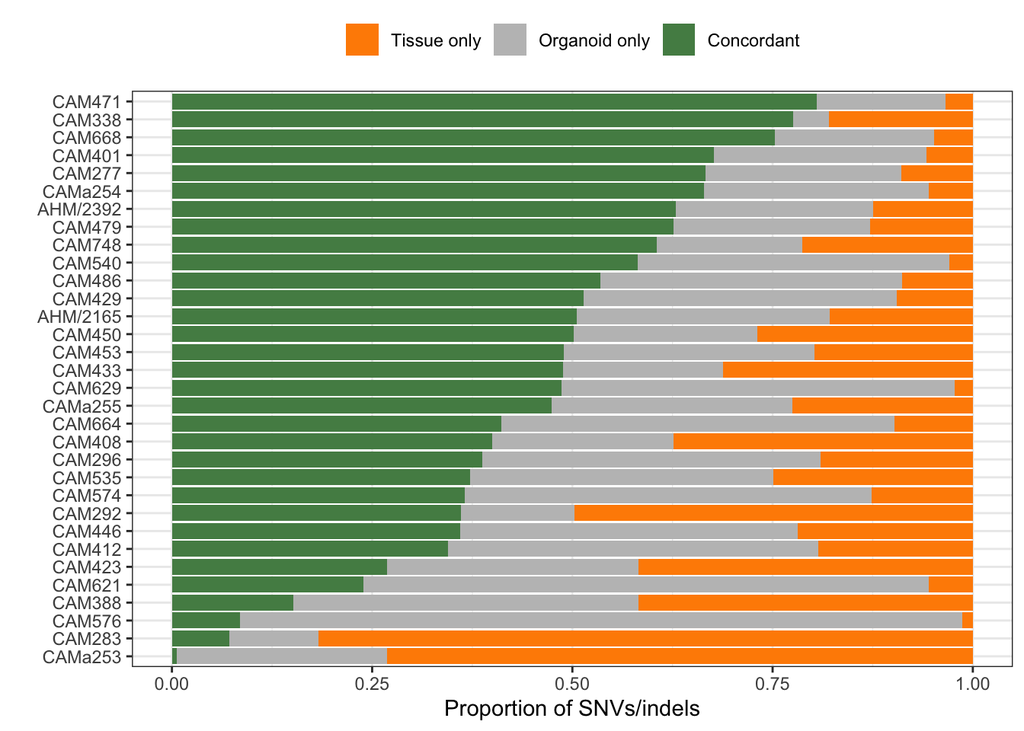

```r
# Remove samples with no matched tissues
muts.shared_summary <- muts.shared_summary %>%
  filter(case_id %in% muts.concordant$case_id) %>%
  mutate(case_id = factor(case_id, levels=muts.concordant$case_id),
         Label = factor(sapply(Label, function(x) str_replace(x,pattern='_', replacement = ' ')),
                        levels = c('Tissue only','Organoid only','Concordant')))

ggplot(muts.shared_summary, aes(x = n, y = case_id, fill = Label)) +
  scale_fill_manual(values = c('darkorange','gray75','palegreen4')) +
  geom_bar(stat = 'identity', position = 'fill') +
  theme_bw() + theme(legend.position = 'top',
                     legend.title = element_blank()) +
  labs(x = 'Proportion of SNVs/indels', y = '')
```

```r
ggsave(filename = 'Results/OrganoidsOAC_ConcordanceWGS.pdf', height = 5)
```

Out of curiosity, could it be the case that sample purity is associated with final concordance?

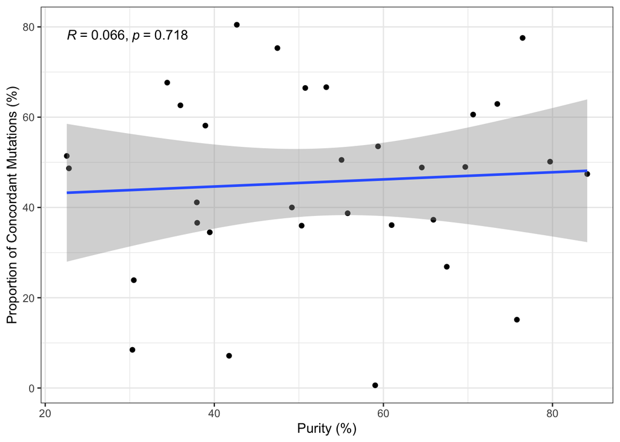

```r
muts.oac_ann$case_id2 <- sapply(muts.oac_ann$column_name, function(x) strsplit(x,split='_')[[1]][1])
muts.concordant_purity <- merge(x = muts.concordant[,c('case_id','percentage_Concordant')],
                                y = muts.oac_ann[muts.oac_ann$specimen_source == 'tissue',c('case_id2','Purity')],
                                by.x = 'case_id', by.y = 'case_id2')

ggplot(muts.concordant_purity, aes(x = 100*Purity, y = 100*percentage_Concordant)) +
  theme_bw() +
  geom_point() + geom_smooth(method = 'lm') + stat_cor(p.accuracy = 0.001) +
  labs(x = 'Purity (%)', y = 'Proportion of Concordant Mutations (%)')
```